# HURT 100 Geezer Meter

**UPDATE FOR 2025**: HURT moved from a long-established practice of reporting results on [Ultrasignup](https://ultrasignup.com/) to instead using [Webscorer](https://www.webscorer.com/). This complicates things a bit, as (i) older results are no longer (easily) accesible on Ultrasignup; and (ii) two different formats of results need to be intergrated. But the biggest complication is that the Webscorer results do not include ages, just age ranges.

The task for 2025 is made much easier by the fact that 2025 was not a good year for us geezers. Of the seven starters in the 60+ category (all men, one 70+), none finished.

Because Webscorer doesn’t report ages, I can’t tell you the age of the oldest finisher—-though 10 men and 4 women in the 50-59 range finished the race, which is pretty awesome.

### Some statistics regarding senior performance in HURT

The [HURT 100](http://hurt100.com) is said to be one of the hardest 100 mile trail races around. As noted, no one 60 or older finished the race in 2025. Compare that to Western States, which in its 2023 edition had 13 finishers age 60+. Or UTMB, which had 37 finishers 60+, including one aged 70+!! So just how rare is it for an age 60+ runner to finish HURT?

As of 2025, a total of 90 (81 men, 9 women) runners 60 years or older have attempted HURT, with the largest numbers occurring in the three most recent years.

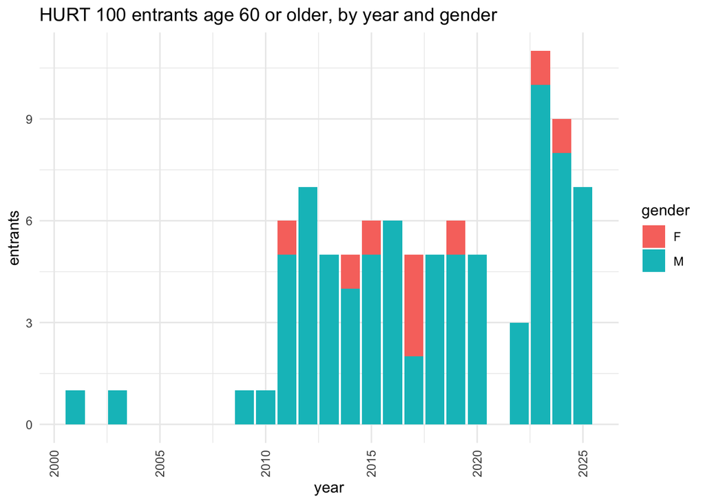

And yet only 9 of these runners have finished (at age 60+). Here’s a list of those runners who did it, ordered by their finish times:

| name | age | time | state | year |
| --- | --- | --- | --- | --- |
| Alfred Bogenhuber | 61 | 28:40:00 |  | 2001 |
| Ernie Floyd | 63 | 33:31:51 | UT | 2018 |
| Kuni Yamagata | 63 | 34:05:44 | CA | 2017 |
| Ernie Floyd | 61 | 34:11:42 | UT | 2016 |
| Michael Muench | 60 | 34:22:00 | HI | 2010 |
| Ernie Floyd | 67 | 34:23:27 | UT | 2022 |
| Gary Marr | 60 | 35:29:00 | WA | 2012 |
| Hans-Dieter Weisshaar | 62 | 35:46:00 |  | 2003 |
| Kuni Yamagata | 65 | 35:51:17 | CA | 2019 |
| Frederick F Davis III | 61 | 35:53:00 |  | 2009 |

[output cut: 3 more lines]

Incredibly, several of these runners have done it more than once, as shown in the `over60` column below.

| name | attempts | finishes | over60 |
| --- | --- | --- | --- |
| Ernie Floyd | 10 | 3 | 3 |
| Mike Smith | 13 | 6 | 2 |
| Kuni Yamagata | 4 | 2 | 2 |
| Michael Muench | 6 | 3 | 1 |
| Gary Marr | 8 | 2 | 1 |
| Alfred Bogenhuber | 1 | 1 | 1 |
| Glen Oshiro | 2 | 2 | 1 |
| Hans-Dieter Weisshaar | 1 | 1 | 1 |
| Frederick F Davis III | 5 | 2 | 1 |

So just three people have more than one HURT finish at age 60 or over. Ernie Floyd has the most geezer finishes, and all of his HURT finishes were completed at age 60+. Wow! Alfred Bogenhuber and Hans-Dieter Weisshaar are the only people to have completed HURT on their first attempt at age 60+.

In contrast, most of these runners do have previous finishes before age 60 – though perhaps surprizingly, they weren’t all that much younger when the had their earlier finishes.

| name | age | time | year |
| --- | --- | --- | --- |
| Frederick F Davis III | 55 | 35:26:00 | 2003 |
| Gary Marr | 58 | 32:53:00 | 2010 |
| Michael Muench | 59 | 35:50:00 | 2009 |
| Michael Muench | 57 | 35:50:00 | 2007 |
| Glen Oshiro | 57 | 34:52:00 | 2015 |
| Mike Smith | 59 | 35:50:34 | 2017 |
| Mike Smith | 56 | 35:49:00 | 2014 |
| Mike Smith | 55 | 35:49:00 | 2013 |
| Mike Smith | 52 | 35:46:00 | 2010 |

A total of 200 people have completed HURT in their pre-senior (age 50-59), but most of these have yet to finish HURT at age 60+.

Data gleaned from [Ultrasignup](http://ultrasignup.com) using the [jsonlite](https://cran.r-project.org/web/packages/jsonlite/index.html) package for R.  
This site is not affilated with [HURT](http://hurt100.com) or Ultrasignup. View code on [Github](https://github.com/gmholton/hurt/).  
Updated 2025-05-26 by *gary dot holton at gmail*. Comments and corrections welcome.